# Algorytn *k*NN

## Przykład 1.

Korzystając ze zbioru danych **`spam{kernlab}`** przygotuj klasyfikator z wykorzystaniem algorytmu *k*NN, dla 15 e-maili.

### Pobranie danych

```r
library("kernlab")
data("spam")
sort(round(colMeans(spam[,-58]),2))
```

```
            parts             table charSquarebracket        conference                cs     charSemicolon          charHash
             0.01              0.01              0.02              0.03              0.04              0.04              0.04
        addresses            num857            num415          original           receive            report            telnet
             0.05              0.05              0.05              0.05              0.06              0.06              0.06
           direct             num3d                pm           project        charDollar             order            people
             0.06              0.07              0.08              0.08              0.08              0.09              0.09
           credit             money              make              over            num000               lab              labs
             0.09              0.09              0.10              0.10              0.10              0.10              0.10
             data        technology            remove          internet             num85              font            num650
             0.10              0.10              0.11              0.11              0.11              0.12              0.12
          meeting          business           num1999  charRoundbracket             email               edu           address
             0.13              0.14              0.14              0.14              0.18              0.18              0.21
             mail              free               hpl   charExclamation               all                re               our
             0.24              0.25              0.27              0.27              0.28              0.30              0.31
             will                hp            george              your               you        capitalAve       capitalLong
             0.54              0.55              0.77              0.81              1.66              5.19             52.17
     capitalTotal
           283.29
```

Przeglądając zbiór danych możemy zauważyć, że:

```r
table(spam$type)
```

```
nonspam    spam
   2788    1813
```

Dla ułatwienia prezentacji ze zbioru oryginalnego wybranych zostanie 15 przypadków, a zestaw zmiennych (termów opisujących listy) ograniczonych zostanie do dwóch: *`free`* i *`will`*.

```r
set.seed(13) #jeżeli chcesz otrzymać te same wyniki musisz zamrozić wariant losowania
tym <- spam[spam$free > mean(spam$free) & spam$will > mean(spam$will), c("free","will","type")]
wyborWierszy <- sample(1:nrow(tym), 15)
spam15 <- tym[wyborWierszy, ]
```

Zbiór do analizy:

```r
spam15
```

|  | free | will | type |
| --- | --- | --- | --- |
| 1375 | 1.14 | 1.30 | spam |
| 2197 | 0.99 | 0.99 | nonspam |
| 423 | 0.49 | 0.99 | spam |
| 1100 | 0.44 | 0.88 | spam |
| 1382 | 1.12 | 1.50 | spam |
| 773 | 0.49 | 2.24 | spam |
| 1652 | 1.13 | 1.22 | spam |
| 1172 | 0.26 | 0.97 | spam |
| 1309 | 0.65 | 0.65 | spam |
| 1733 | 0.26 | 0.89 | spam |

[output cut: 5 more lines]

Zbiór **`spam15`** jest “przyjazny” wizualizacji

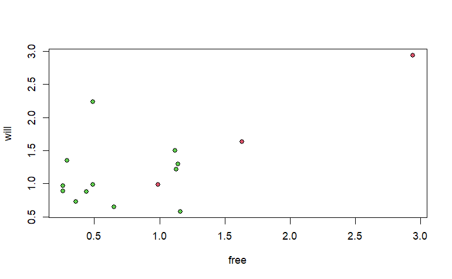

```r
plot(spam15$free, spam15$will,
     xlab = "free", ylab = "will",
     pch = 21, bg = as.numeric(spam15$type)+1)
```

### Obliczenie odległości

Nowy obiekt (e-mail, dla którego znamy wagi termów, ale nie znamy klasy), zostanie dopisany do zbioru **`spam15`**

```r
nowy <- c(0.98, 2.1, NA)
spam15 <- rbind(spam15, nowy)
```

Na wykresie zobaczymy go w relacji do pozostałych obiektów:

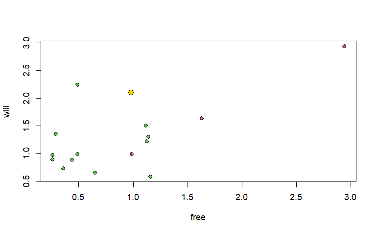

```r
plot(spam15$free[-nrow(spam15)], spam15$will[-nrow(spam15)],
     xlab = "free", ylab = "will",
     pch = 21, bg = as.numeric(spam15$type)+1)
points(spam15$free[nrow(spam15)], spam15$will[nrow(spam15)],
       pch = 21, bg = "gold", cex = 1.5)
```

Odległość każdego obiektu od nowego może zostać obliczona za pomocą [wielu różnych miar odległości](https://en.wikipedia.org/wiki/Distance). Tutaj wybierzamy tą najbardziej naturalną - euklidesową:

Jeżeli mamy dwa punkty w n-wymiarowej przestrzeni $a=(x_1,x_2,\ldots,x_n)$, $b=(y_1,y_2,\ldots,y_n)$ to odległość miedzy nimi obliczymy:

$$d(a,b)=\sqrt{(x_1-y_1)^2+(x_2-y_2)^2+\cdots+(x_n-y_n)^2}$$

```r
spam15$odleg <- c(sqrt((spam15$free - spam15$free[nrow(spam15)])^2+
                         (spam15$will - spam15$will[nrow(spam15)])^2))
spam15
```

|  | free | will | type | odleg |
| --- | --- | --- | --- | --- |
| 1375 | 1.14 | 1.30 | spam | 0.8158431 |
| 2197 | 0.99 | 0.99 | nonspam | 1.1100450 |
| 423 | 0.49 | 0.99 | spam | 1.2133425 |
| 1100 | 0.44 | 0.88 | spam | 1.3341664 |
| 1382 | 1.12 | 1.50 | spam | 0.6161169 |
| 773 | 0.49 | 2.24 | spam | 0.5096077 |
| 1652 | 1.13 | 1.22 | spam | 0.8926926 |
| 1172 | 0.26 | 0.97 | spam | 1.3398881 |
| 1309 | 0.65 | 0.65 | spam | 1.4870777 |
| 1733 | 0.26 | 0.89 | spam | 1.4080128 |

[output cut: 6 more lines]

Na wykresie można odległości przestawić za pomocą odcinków:

```r
plot(spam15$free[-nrow(spam15)], spam15$will[-nrow(spam15)],
     xlab = "free", ylab = "will",
     pch = 21, bg = as.numeric(spam15$type)+1)
points(spam15$free[nrow(spam15)], spam15$will[nrow(spam15)],
       pch = 21, bg = "gold", cex = 1.5)
```

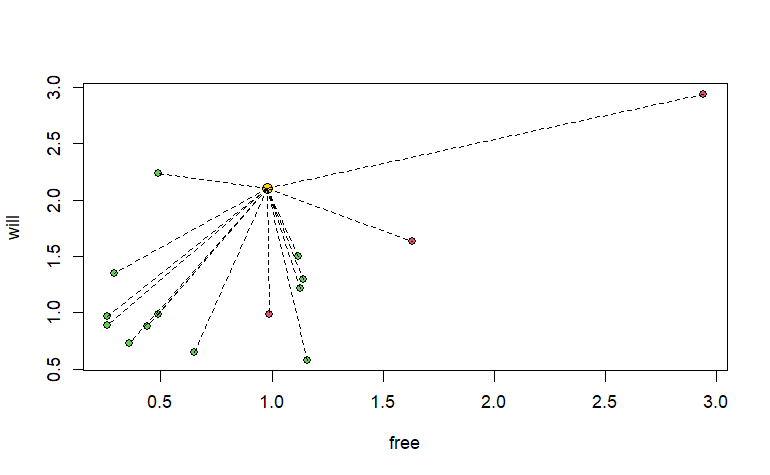

```r
segments(spam15$free[nrow(spam15)], spam15$will[nrow(spam15)],
         spam15$free[-nrow(spam15)], spam15$will[-nrow(spam15)],
         lty = 2, lwd = 0.5)
```

### Wyznaczenia rankingu punktów wobec nowego punktu

Kolejnym krokiem algorytmu jest przypisanie rang (od najbliższego do najdalszego) kolejnym punktom

```r
spam15$rangi <- rank(spam15$odleg)-1
spam15
```

|  | free | will | type | odleg | rangi |
| --- | --- | --- | --- | --- | --- |
| 1375 | 1.14 | 1.30 | spam | 0.8158431 | 4 |
| 2197 | 0.99 | 0.99 | nonspam | 1.1100450 | 7 |
| 423 | 0.49 | 0.99 | spam | 1.2133425 | 8 |
| 1100 | 0.44 | 0.88 | spam | 1.3341664 | 9 |
| 1382 | 1.12 | 1.50 | spam | 0.6161169 | 2 |
| 773 | 0.49 | 2.24 | spam | 0.5096077 | 1 |
| 1652 | 1.13 | 1.22 | spam | 0.8926926 | 5 |
| 1172 | 0.26 | 0.97 | spam | 1.3398881 | 10 |
| 1309 | 0.65 | 0.65 | spam | 1.4870777 | 12 |
| 1733 | 0.26 | 0.89 | spam | 1.4080128 | 11 |

[output cut: 6 more lines]

```r
plot(spam15$free[-nrow(spam15)], spam15$will[-nrow(spam15)],
     xlab = "free", ylab = "will",
     pch = 21, bg = as.numeric(spam15$type)+1)
points(spam15$free[nrow(spam15)], spam15$will[nrow(spam15)],
       pch = 21, bg = "gold", cex = 1.5)
```

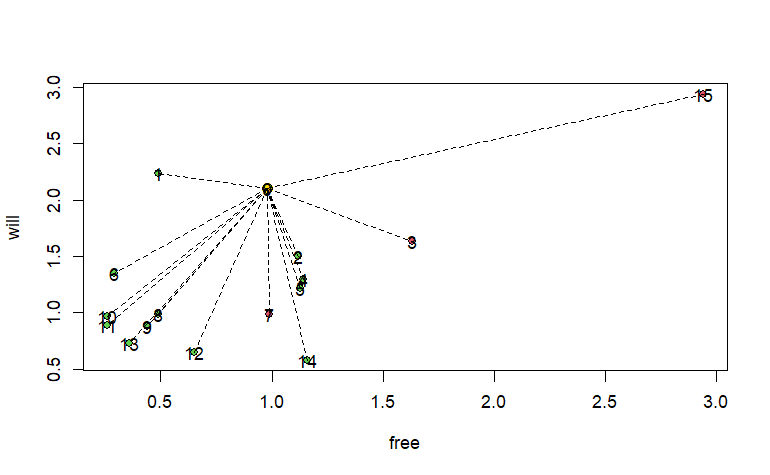

```r
segments(spam15$free[nrow(spam15)], spam15$will[nrow(spam15)],
         spam15$free[-nrow(spam15)], spam15$will[-nrow(spam15)],
         lty = 2, lwd = 0.5)
text(spam15[order(spam15$rangi),1], spam15[order(spam15$rangi),2], labels = spam15[order(spam15$rangi),5])
```

### Wskazanie większościowej klasy *k* najbliższych sąsiadów

Kolejnym krokiem algorytmu jest ustalenie, która Z klas stanowi większość wśród *k najbliższych sąsiadów* (według zasady *majority vote*). Załużmy, że w analizownym przykładzie *k* wynosi **3**.

Wybranie klas (spam/nonspam) *k* najbliższych punktów

```r
as.character(knajbli)
```

```
[1] "spam"    "spam"    "nonspam"
```

Ustalenie nazwy klasy która stanowi większość wśród *k* najbliższych punktów

```r
(czestosc <- as.data.frame(table(knajbli)))
```

| knajbli | Freq |
| --- | --- |
| nonspam | 1 |
| spam | 2 |

```r
(klasa <- as.character(czestosc[czestosc$Freq == max(czestosc$Freq), 1]))
```

```
[1] "spam"
```

Wygerowania wyniku:

```r
cat("Nowy obiekt należy do klasy:", klasa)
```

```
Nowy obiekt należy do klasy: spam
```

## Przykład 2.

Korzystając ze zbioru danych **`spam{kernlab}`** przygotuj klasyfikator z wykorzystaniem algorytmu kNN, dla całego zbioru.

### Pobranie danych

```r
library("kernlab")
data("spam")
```

Przeglądając zbiór danych możemy zauważyć, że:

```r
table(spam$type)
```

```
nonspam    spam
   2788    1813
```

### Analiza właściwa

#### Podział na zbiór uczący i testowy

```r
library("caret")
wUczacym <- createDataPartition(spam$type, p = 0.7, list = FALSE)
Uczacy <- spam[wUczacym,]
Testowy <- spam[-wUczacym,]
```

#### Budowa klasyfikatora z jednoczesną predykcją

```r
head(modelSpamKnn) |> as.character()
```

```
[1] "spam"    "spam"    "nonspam" "nonspam" "nonspam" "spam"
```

#### Ocena klasyfikatora - macierz pomyłek

```r
confusionMatrix(modelSpamKnn, Testowy$type)
```

```
Confusion Matrix and Statistics

          Reference
Prediction nonspam spam
   nonspam     674  178
   spam        162  365

               Accuracy : 0.7534
                 95% CI : (0.7298, 0.776)
    No Information Rate : 0.6062
    P-Value [Acc > NIR] : <2e-16

                  Kappa : 0.4809

 Mcnemar's Test P-Value : 0.4159

            Sensitivity : 0.8062
            Specificity : 0.6722
         Pos Pred Value : 0.7911
         Neg Pred Value : 0.6926
             Prevalence : 0.6062
         Detection Rate : 0.4888
   Detection Prevalence : 0.6178
      Balanced Accuracy : 0.7392

       'Positive' Class : nonspam
```